# Analysis

Zach Houghton

2023-12-05

```r
#devtools::install_github("m-clark/visibly") to install the package to make the 3d plot
library(tidyverse)
library(brms)
library(mgcv)
library(mgcViz)
library(rgl)
#library(visibly)
library(schoenberg)
library(ggpubr)
library(mdthemes)
library(broom)
library(tidybayes)
library(ggdist)
```

## Analysis of English Recognizability Experiment

The purpose of this script is to analyze the data collected from the recognizability experiment.

### Read in Data

First we’ll read in our data and organize the data in a tidy format.

```r
data = read.csv('Database_AllParticipants_Recognizability_Experiment2_330703_2023-11-10_18h36.32_faa93908-1176-4bbf-ba5e-5e6fab9181f2.csv', quote = "\"")

data = data %>%
  dplyr::select(participant, Word, textbox.text, textbox_2.text, textbox_3.text, textbox_5.text, textbox_6.text, textbox_4.text, Item, Condition, Type, Sentences, response.corr, response.rt, PhrasalVerb, Frequency, Predictability, OnsetTime, OffsetTime, Duration
) %>%
  rename(age = textbox.text,
         gender = textbox_2.text,
         race = textbox_3.text,
         native_lang = textbox_5.text,
         other_langs = textbox_6.text,
         place_of_birth = textbox_4.text) %>%
  mutate(gender = lead(gender)) %>%                   #this is so that these values
  mutate(race = lead(race, n = 2)) %>%                #are all in the same row
  mutate(native_lang = lead(native_lang, n = 3)) %>%  #instead of all being in
  mutate(other_langs = lead(other_langs, n = 4)) %>%  #separate rows
  mutate(place_of_birth = lead(place_of_birth, n = 5))#it's admittedly a bit of a janky fix


data_analysis = data

#data_analysis$OffsetTime[data_analysis$Item==221] = 2.93 #error in the recording of the offset time

#data_analysis = data_analysis %>%
  #mutate(frequency_per_million = Frequency / 2050000000 * 1000000) # need to fix frequency values

#exclude participants who didn't complete the experiment
```

Let’s inspect the different languages spoken by our participants to make sure they’re all native English speakers:

```r
unique(data_analysis$native_lang)
```

```
##  [1] ""                                   "English"
##  [3] "English/Cantonese"                  "english"
##  [5] "SPANISH"                            "ENGLISH"
##  [7] "Chinese "                           "\n"
##  [9] "marathi"                            "korean"
## [11] "vietnamese"                         "english "
## [13] "engilsh"                            "English "
## [15] "English and Tagalog "               "telugu"
## [17] "English and Tagalog"                "english, cantonese, and vietnamese"
## [19] "spanish"                            "Chinese"
## [21] "chinese"                            "Burmese"
## [23] "farsi"                              "English/Korean"
## [25] "Vietnamese"                         "Bengali and English"
## [27] "English and Gujarati "              "hindi"
## [29] "Enlish"                             "cantonese"
```

[output cut: 17 more lines]

Let’s exclude participants whose native language is not English (there are a few participants who wrote a non-english language as their native, but said in their demographic questions that they grew up speaking English, I’ve included those people’s data as well).

```r
data_analysis = data_analysis %>%
  group_by(participant) %>%
  filter(any(native_lang %in% c('english', 'English', 'ENGLISH', 'engilsh', 'English ', 'english ', 'Enlish', 'EENNGGLLIISSHH', 'Englsih', 'enlgish', 'ENglish', 'American English', 'English\n')))
```

Next let’s exclude participants with an accuracy less than 70%:

```r
data_analysis = data_analysis %>%
  group_by(participant) %>%
  mutate(accuracy = mean(response.corr, na.rm = T))

data_analysis = data_analysis %>%
  drop_na(Condition)

data_analysis = data_analysis %>%
  group_by(participant) %>%
  mutate(nrows = n()) %>%
  mutate(trial = 1:length(Item))

rows_of_data = data_analysis %>% group_by(nrows) %>% summarize(length(unique(participant)))

data_analysis = data_analysis %>%
  filter(nrows > 300 & nrows < 400)

#data_analysis = data_analysis %>% #should we filter out incorrect responses?
  #filter(response.corr == 1)

#write_csv(data_analysis, 'data_analysis.csv')

participants_excluded = data_analysis %>%
  filter(accuracy < 0.7)

data_analysis = data_analysis %>%
  filter(accuracy > 0.7)

data_analysis$PhrasalVerb = as.factor(data_analysis$PhrasalVerb)
```

Let’s keep track of how many participants we’re excluding this way too:

```r
num_participants_excluded = length(unique(participants_excluded$participant))

num_participants_excluded
```

```
## [1] 44
```

Awesome, only 44 participants had below 70% accuracy.

Lastly, let’s filter out the filler items and get our data ready for the analysis:

```r
data_analysis = data_analysis %>%
  filter(Condition == 'Experimental')
```

```r
data_analysis = data_analysis %>%
  filter(Item != '81' | Item != '159')
```

Before we proceed, we do need to add a final variable which will be our outcome variable. This will be the difference between participants’ response time, and the onset time of the segment. We will go ahead and also exclude any rows with negative values, since this will represent occasions where participants responded *before* hearing the segment. We’re also going to convert seconds to milliseconds here.

```r
#data_analysis_offset = data_analysis %>%
  #mutate(response_time = response.rt - OffsetTime)

#data_analysis_offset_neg_rts = data_analysis_offset %>%
  #filter(response_time < 0)

#data_analysis_offset = data_analysis_offset %>%
  #filter(response_time > 0)

data_analysis = data_analysis %>%
  mutate(response_time = response.rt - OnsetTime)

data_analysis = data_analysis %>%
  filter(response_time > 0 & response_time < 10) #get rid of any responses before the onset and after 10 seconds

#data_analysis_neg_rts = data_analysis %>%
  #filter(response_time < 0)
```

And let’s confirm the number of participants we have:

```r
length(unique(data_analysis$participant))
```

```
## [1] 306
```

Finally, let’s log reaction time, frequency, and predictability:

```r
corpus_size_words = 2111554623
corpus_size_phrase = 1.06491E+12
data_analysis = data_analysis %>%
  mutate(corpus_size = corpus_size_phrase) %>%
  mutate(frequency_per_million = Frequency * 1000000 / corpus_size) %>%
  mutate(log_freq = log(frequency_per_million)) %>% #log frequency per million
  mutate(log_predic = log(Predictability)) %>%
  mutate(log_rt = log(response_time))

#data_analysis_offset = data_analysis_offset %>%
  #mutate(log_freq = log(Frequency)) %>%
  #mutate(log_predic = log(Predictability)) %>%
  #mutate(log_rt = log(response_time))



write_csv(data_analysis, 'data_analysis_cleaned.csv')
```

### GAM model

```r
data_analysis = read_csv('data_analysis_cleaned.csv')
data_analysis$PhrasalVerb[data_analysis$Item == '64'] = 1
data_analysis = data_analysis %>%
  mutate(PhrasalVerb = ifelse(PhrasalVerb == 1, 'phrasal', 'nonphrasal'))
data_analysis$participant = as.factor(data_analysis$participant)
data_analysis$Item = as.factor(data_analysis$Item)
data_analysis$Type = as.factor(data_analysis$Type)
data_analysis$PhrasalVerb = as.factor(data_analysis$PhrasalVerb)
#data_analysis$trial = as.factor(data_analysis$trial)
#data_analysis_offset$participant = as.factor(data_analysis_offset$participant)
#data_analysis_offset$Item = as.factor(data_analysis_offset$Item)
#data_analysis_offset$h_heavily_reduced = as.factor(data_analysis_offset$h_heavily_reduced)


data_analysis %>%
  filter(PhrasalVerb == 'phrasal') %>%
  ungroup() %>%
  summarize(length(unique(Item))) #number of phrasal verbs = 115
```

```
## # A tibble: 1 × 1
##   `length(unique(Item))`
##                    <int>
## 1                    116
```

```r
data_analysis %>%
  filter(PhrasalVerb == 'nonphrasal') %>%
  ungroup() %>%
  summarize(length(unique(Item)))  #number of nonphrasal verbs = 85
```

```
## # A tibble: 1 × 1
##   `length(unique(Item))`
##                    <int>
## 1                     84
```

```r
gam_data = data_analysis %>%
  dplyr::select(participant, Word, Item, Type, log_freq, log_predic, log_rt, Duration, trial, response.corr, response_time, PhrasalVerb) %>%
  filter(Type == 'Phrasal Verb') %>%
  filter(response.corr == 1)

gam_data2 = data_analysis %>%
  dplyr::select(participant, Item, Type, log_freq, log_predic, log_rt, Duration, trial, response.corr, response_time) %>%
  filter(Type == 'Word-Internal') %>%
  filter(response.corr == 1)

gam_data3 = data_analysis %>%
  dplyr::select(participant, Item, Type, log_freq, log_predic, log_rt, Duration, trial, response.corr, response_time) %>%
  filter(Type == 'Word-Internal'|Type == 'Phrasal Verb') %>%
  filter(response.corr == 1)

gam_data_phrasal = gam_data %>%
  filter(PhrasalVerb == 'phrasal')

gam_data_nonphrasal = gam_data %>%
  filter(PhrasalVerb == 'nonphrasal')

gam_data = gam_data %>% mutate(log_freqxpred = log_freq + log_predic)

write_csv(gam_data, 'gam_data.csv')

#gam_data_offset = data_analysis_offset %>%
  #select(participant, Lemma, Item, Type, log_freq, log_predic, log_rt, Duration, response.corr, response_time) %>%
  #filter(Type == 'Target_Segment')
```

Let’s run our analysis:

```r
mod_gam1 = bam(log_rt ~  #note that RT is in seconds
                 te(log_predic, log_freq) + Duration +
                 s(trial, bs = 're') +
                 s(participant, bs = 're') +
                 s(Item, bs = 're') +
                 s(log_predic, log_freq, trial, participant, bs = 're'),
              #method = 'REML',
               #optimizer = 'perf',
              data = gam_data)

summary(mod_gam1)
```

```
##
## Family: gaussian
## Link function: identity
##
## Formula:
## log_rt ~ te(log_predic, log_freq) + Duration + s(trial, bs = "re") +
##     s(participant, bs = "re") + s(Item, bs = "re") + s(log_predic,
##     log_freq, trial, participant, bs = "re")
##
## Parametric coefficients:
##              Estimate Std. Error t value Pr(>|t|)
## (Intercept)  0.009652   0.040992   0.235    0.814
## Duration    -1.839018   0.432244  -4.255  2.1e-05 ***
## ---
## Signif. codes:  0 '***' 0.001 '**' 0.01 '*' 0.05 '.' 0.1 ' ' 1
##
## Approximate significance of smooth terms:
##                                               edf  Ref.df       F p-value
## te(log_predic,log_freq)                    5.5882   5.726   1.861  0.0880 .
## s(trial)                                   0.9857   1.000 115.375  <2e-16 ***
## s(participant)                           296.0028 305.000  39.739  <2e-16 ***
## s(Item)                                  175.4369 195.000  10.682  <2e-16 ***
## s(log_predic,log_freq,trial,participant)  42.9965 306.000   0.459  0.0954 .
## ---
## Signif. codes:  0 '***' 0.001 '**' 0.01 '*' 0.05 '.' 0.1 ' ' 1
##
## R-sq.(adj) =  0.334   Deviance explained = 34.7%
## fREML =  17315  Scale est. = 0.20467   n = 26347
```

```r
saveRDS(mod_gam1, 'mod_gam1.rds')

mod_gam_phrasal_nonphrasal = bam(log_rt ~  #note that RT is in log seconds
                 PhrasalVerb +
                 te(log_predic, log_freq, by = PhrasalVerb) + Duration +
                 s(trial, bs = 're') +
                 s(participant, bs = 're') +
                 s(Item, bs = 're') +
                 s(log_predic, log_freq, trial, participant, bs = 're'),
              #method = 'REML',
               #optimizer = 'perf',
              data = gam_data)


summary(mod_gam_phrasal_nonphrasal)
```

```
##
## Family: gaussian
## Link function: identity
##
## Formula:
## log_rt ~ PhrasalVerb + te(log_predic, log_freq, by = PhrasalVerb) +
##     Duration + s(trial, bs = "re") + s(participant, bs = "re") +
##     s(Item, bs = "re") + s(log_predic, log_freq, trial, participant,
##     bs = "re")
##
## Parametric coefficients:
##                     Estimate Std. Error t value Pr(>|t|)
## (Intercept)        -0.003393   0.044779  -0.076    0.940
## PhrasalVerbphrasal  0.013555   0.020148   0.673    0.501
## Duration           -1.776408   0.442814  -4.012 6.05e-05 ***
## ---
## Signif. codes:  0 '***' 0.001 '**' 0.01 '*' 0.05 '.' 0.1 ' ' 1
##
## Approximate significance of smooth terms:
##                                                    edf  Ref.df       F p-value
## te(log_predic,log_freq):PhrasalVerbnonphrasal   3.9288   3.976   1.462  0.2144
## te(log_predic,log_freq):PhrasalVerbphrasal      4.0677   4.121   1.271  0.2428
## s(trial)                                        0.9857   1.000 115.655  <2e-16
## s(participant)                                295.9949 305.000  39.827  <2e-16
## s(Item)                                       172.5895 191.000  10.935  <2e-16
## s(log_predic,log_freq,trial,participant)       42.9721 306.000   0.458  0.0955
##
## te(log_predic,log_freq):PhrasalVerbnonphrasal
## te(log_predic,log_freq):PhrasalVerbphrasal
## s(trial)                                      ***
## s(participant)                                ***
## s(Item)                                       ***
## s(log_predic,log_freq,trial,participant)      .
## ---
## Signif. codes:  0 '***' 0.001 '**' 0.01 '*' 0.05 '.' 0.1 ' ' 1
##
## R-sq.(adj) =  0.334   Deviance explained = 34.7%
## fREML =  17318  Scale est. = 0.20467   n = 26347
```

```r
mod_gam_phrasal_nonphrasal2 = bam(log_rt ~  #note that RT is in log seconds
                 te(log_predic, log_freq, by = PhrasalVerb) + Duration +
                 s(trial, bs = 're') +
                 s(participant, bs = 're') +
                 s(Item, bs = 're') +
                 s(log_predic, log_freq, trial, participant, bs = 're'),
              #method = 'REML',
               #optimizer = 'perf',
              data = gam_data)


summary(mod_gam_phrasal_nonphrasal2)
```

```
##
## Family: gaussian
## Link function: identity
##
## Formula:
## log_rt ~ te(log_predic, log_freq, by = PhrasalVerb) + Duration +
##     s(trial, bs = "re") + s(participant, bs = "re") + s(Item,
##     bs = "re") + s(log_predic, log_freq, trial, participant,
##     bs = "re")
##
## Parametric coefficients:
##             Estimate Std. Error t value Pr(>|t|)
## (Intercept)  0.00791    0.04151   0.191    0.849
## Duration    -1.81767    0.43819  -4.148 3.36e-05 ***
## ---
## Signif. codes:  0 '***' 0.001 '**' 0.01 '*' 0.05 '.' 0.1 ' ' 1
##
## Approximate significance of smooth terms:
##                                                    edf  Ref.df       F p-value
## te(log_predic,log_freq):PhrasalVerbnonphrasal   3.9491   3.997   1.442  0.2188
## te(log_predic,log_freq):PhrasalVerbphrasal      4.0286   4.081   1.265  0.2524
## s(trial)                                        0.9857   1.000 115.651  <2e-16
## s(participant)                                295.9952 305.000  39.808  <2e-16
## s(Item)                                       173.4841 192.000  10.907  <2e-16
## s(log_predic,log_freq,trial,participant)       42.9890 306.000   0.459  0.0954
##
## te(log_predic,log_freq):PhrasalVerbnonphrasal
## te(log_predic,log_freq):PhrasalVerbphrasal
## s(trial)                                      ***
## s(participant)                                ***
## s(Item)                                       ***
## s(log_predic,log_freq,trial,participant)      .
## ---
## Signif. codes:  0 '***' 0.001 '**' 0.01 '*' 0.05 '.' 0.1 ' ' 1
##
## R-sq.(adj) =  0.334   Deviance explained = 34.7%
## fREML =  17315  Scale est. = 0.20467   n = 26347
```

```r
mod_bam_inter = bam(log_rt ~ s(log_freq) + s(log_predic) + s(log_freqxpred) +
                 Duration +
                 s(participant, bs = 're') +
                 s(Item, bs = 're') +
                 s(log_predic, participant, bs = 're'),
              method = 'REML',
              data = gam_data)

summary(mod_bam_inter)
```

```
##
## Family: gaussian
## Link function: identity
##
## Formula:
## log_rt ~ s(log_freq) + s(log_predic) + s(log_freqxpred) + Duration +
##     s(participant, bs = "re") + s(Item, bs = "re") + s(log_predic,
##     participant, bs = "re")
##
## Parametric coefficients:
##             Estimate Std. Error t value Pr(>|t|)
## (Intercept)  0.05504    0.04045   1.361    0.174
## Duration    -1.86115    0.42973  -4.331 1.49e-05 ***
## ---
## Signif. codes:  0 '***' 0.001 '**' 0.01 '*' 0.05 '.' 0.1 ' ' 1
##
## Approximate significance of smooth terms:
##                                 edf    Ref.df      F p-value
## s(log_freq)               2.432e+00 2.485e+00  1.677   0.320
## s(log_predic)             1.876e+00 1.918e+00  3.283   0.026 *
## s(log_freqxpred)          2.783e-03 2.966e-03  0.050   0.990
## s(participant)            2.963e+02 3.050e+02 37.597  <2e-16 ***
## s(Item)                   1.764e+02 1.960e+02 10.636  <2e-16 ***
## s(log_predic,participant) 9.378e-02 3.050e+02  0.000   0.930
## ---
## Signif. codes:  0 '***' 0.001 '**' 0.01 '*' 0.05 '.' 0.1 ' ' 1
##
## Rank: 840/841
## R-sq.(adj) =   0.33   Deviance explained = 34.3%
## -REML =  17353  Scale est. = 0.20563   n = 26347
```

```r
mod_bam_freq = bam(log_rt ~ PhrasalVerb + s(log_freq, by = PhrasalVerb) +
                Duration +
                 s(participant, bs = 're') +
                 s(Item, bs = 're') +
                 s(log_freq, participant, bs = 're'),
              method = 'REML',
              data = gam_data)

summary(mod_bam_freq)
```

```
##
## Family: gaussian
## Link function: identity
##
## Formula:
## log_rt ~ PhrasalVerb + s(log_freq, by = PhrasalVerb) + Duration +
##     s(participant, bs = "re") + s(Item, bs = "re") + s(log_freq,
##     participant, bs = "re")
##
## Parametric coefficients:
##                    Estimate Std. Error t value Pr(>|t|)
## (Intercept)         0.04082    0.04437   0.920    0.358
## PhrasalVerbphrasal  0.01001    0.02024   0.495    0.621
## Duration           -1.77045    0.44179  -4.007 6.15e-05 ***
## ---
## Signif. codes:  0 '***' 0.001 '**' 0.01 '*' 0.05 '.' 0.1 ' ' 1
##
## Approximate significance of smooth terms:
##                                       edf  Ref.df      F  p-value
## s(log_freq):PhrasalVerbnonphrasal   2.021   2.061  1.904 0.155885
## s(log_freq):PhrasalVerbphrasal      1.004   1.005  0.045 0.834582
## s(participant)                    294.356 305.000 48.421  < 2e-16 ***
## s(Item)                           177.448 195.000 11.534  < 2e-16 ***
## s(log_freq,participant)            70.886 305.000  3.095 0.000741 ***
## ---
## Signif. codes:  0 '***' 0.001 '**' 0.01 '*' 0.05 '.' 0.1 ' ' 1
##
## R-sq.(adj) =  0.333   Deviance explained = 34.7%
## -REML =  17353  Scale est. = 0.2049    n = 26347
```

```r
#saveRDS(mod_bam_freq, 'mod_bam_freq.rds')

mod_bam_predic = bam(log_rt ~ PhrasalVerb + s(log_predic, by = PhrasalVerb) +
                 Duration +
                 s(participant, bs = 're') +
                 s(Item, bs = 're') +
                 s(log_predic, participant, bs = 're'),
              method = 'REML',
              data = gam_data)



summary(mod_bam_predic)
```

```
##
## Family: gaussian
## Link function: identity
##
## Formula:
## log_rt ~ PhrasalVerb + s(log_predic, by = PhrasalVerb) + Duration +
##     s(participant, bs = "re") + s(Item, bs = "re") + s(log_predic,
##     participant, bs = "re")
##
## Parametric coefficients:
##                    Estimate Std. Error t value Pr(>|t|)
## (Intercept)         0.04627    0.04402   1.051    0.293
## PhrasalVerbphrasal  0.01221    0.02008   0.608    0.543
## Duration           -1.84409    0.43705  -4.219 2.46e-05 ***
## ---
## Signif. codes:  0 '***' 0.001 '**' 0.01 '*' 0.05 '.' 0.1 ' ' 1
##
## Approximate significance of smooth terms:
##                                           edf  Ref.df      F p-value
## s(log_predic):PhrasalVerbnonphrasal   1.00148   1.002  3.182  0.0742 .
## s(log_predic):PhrasalVerbphrasal      1.00127   1.001  3.141  0.0761 .
## s(participant)                      296.31801 305.000 37.632  <2e-16 ***
## s(Item)                             178.16446 195.000 11.464  <2e-16 ***
## s(log_predic,participant)             0.07205 305.000  0.000  0.9302
## ---
## Signif. codes:  0 '***' 0.001 '**' 0.01 '*' 0.05 '.' 0.1 ' ' 1
##
## R-sq.(adj) =   0.33   Deviance explained = 34.3%
## -REML =  17357  Scale est. = 0.20563   n = 26347
```

```r
#saveRDS(mod_bam_predic, 'mod_bam_predic.rds')

mod_bam_only_freq = bam(log_rt ~ s(log_freq) +
                Duration +
                 s(participant, bs = 're') +
                 s(Item, bs = 're') +
                 s(log_freq, participant, bs = 're'),
              method = 'REML',
              data = gam_data)

summary(mod_bam_only_freq)
```

```
##
## Family: gaussian
## Link function: identity
##
## Formula:
## log_rt ~ s(log_freq) + Duration + s(participant, bs = "re") +
##     s(Item, bs = "re") + s(log_freq, participant, bs = "re")
##
## Parametric coefficients:
##             Estimate Std. Error t value Pr(>|t|)
## (Intercept)  0.05119    0.04095   1.250    0.211
## Duration    -1.82042    0.43570  -4.178 2.95e-05 ***
## ---
## Signif. codes:  0 '***' 0.001 '**' 0.01 '*' 0.05 '.' 0.1 ' ' 1
##
## Approximate significance of smooth terms:
##                             edf  Ref.df      F  p-value
## s(log_freq)               2.597   2.651  1.988 0.237715
## s(participant)          294.362 305.000 48.385  < 2e-16 ***
## s(Item)                 178.567 197.000 11.249  < 2e-16 ***
## s(log_freq,participant)  70.822 305.000  3.090 0.000742 ***
## ---
## Signif. codes:  0 '***' 0.001 '**' 0.01 '*' 0.05 '.' 0.1 ' ' 1
##
## R-sq.(adj) =  0.333   Deviance explained = 34.7%
## -REML =  17347  Scale est. = 0.20489   n = 26347
```

```r
mod_bam_only_predic =  bam(log_rt ~ s(log_predic) +
                 Duration +
                 s(participant, bs = 're') +
                 s(Item, bs = 're') +
                 s(log_predic, participant, bs = 're'),
              method = 'REML',
              data = gam_data)
summary(mod_bam_only_predic)
```

```
##
## Family: gaussian
## Link function: identity
##
## Formula:
## log_rt ~ s(log_predic) + Duration + s(participant, bs = "re") +
##     s(Item, bs = "re") + s(log_predic, participant, bs = "re")
##
## Parametric coefficients:
##             Estimate Std. Error t value Pr(>|t|)
## (Intercept)  0.05642    0.04034   1.399    0.162
## Duration    -1.87881    0.42773  -4.392 1.13e-05 ***
## ---
## Signif. codes:  0 '***' 0.001 '**' 0.01 '*' 0.05 '.' 0.1 ' ' 1
##
## Approximate significance of smooth terms:
##                                 edf  Ref.df      F p-value
## s(log_predic)               1.82738   1.867  3.346   0.023 *
## s(participant)            296.32209 305.000 37.593  <2e-16 ***
## s(Item)                   178.94943 197.000 11.033  <2e-16 ***
## s(log_predic,participant)   0.09018 305.000  0.000   0.930
## ---
## Signif. codes:  0 '***' 0.001 '**' 0.01 '*' 0.05 '.' 0.1 ' ' 1
##
## R-sq.(adj) =   0.33   Deviance explained = 34.3%
## -REML =  17350  Scale est. = 0.20563   n = 26347
```

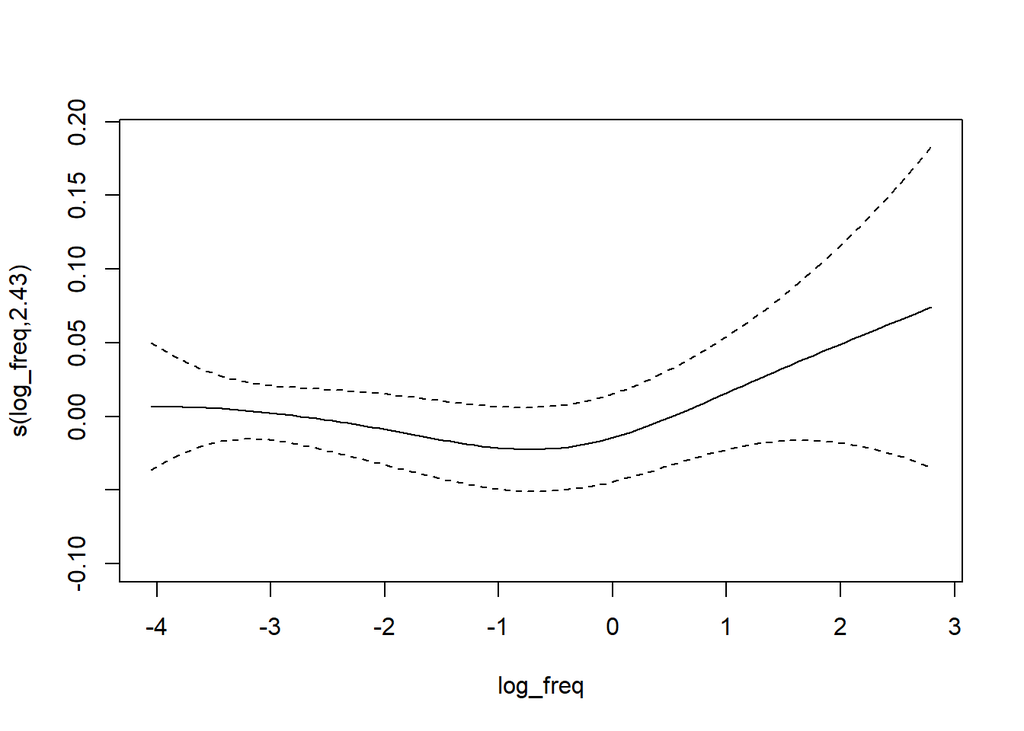

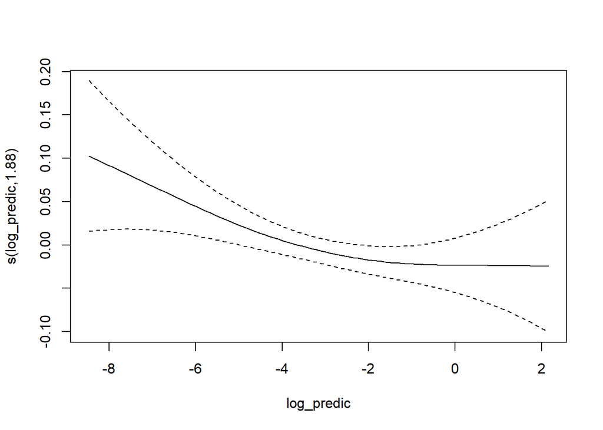

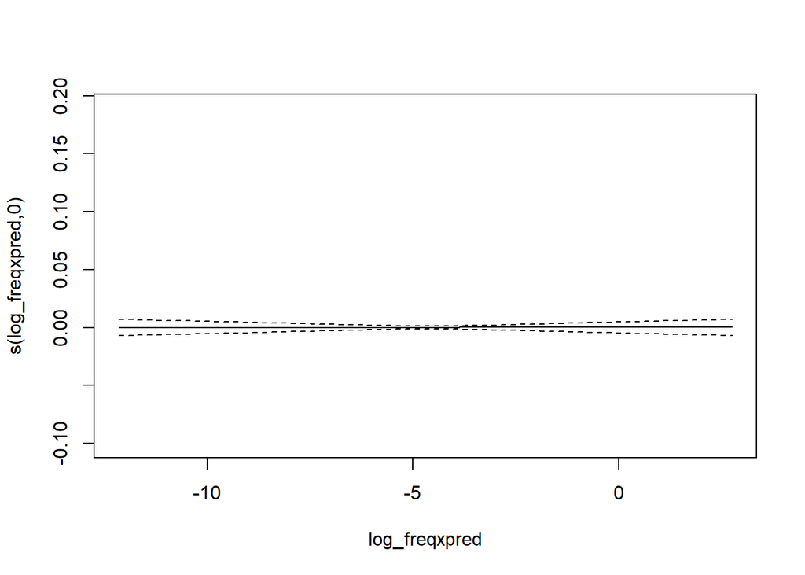

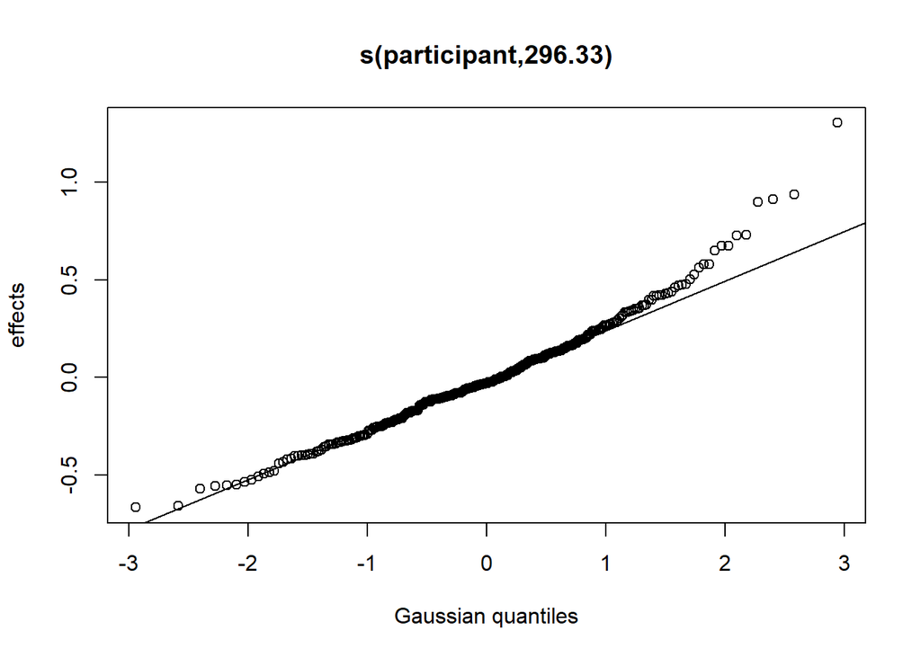

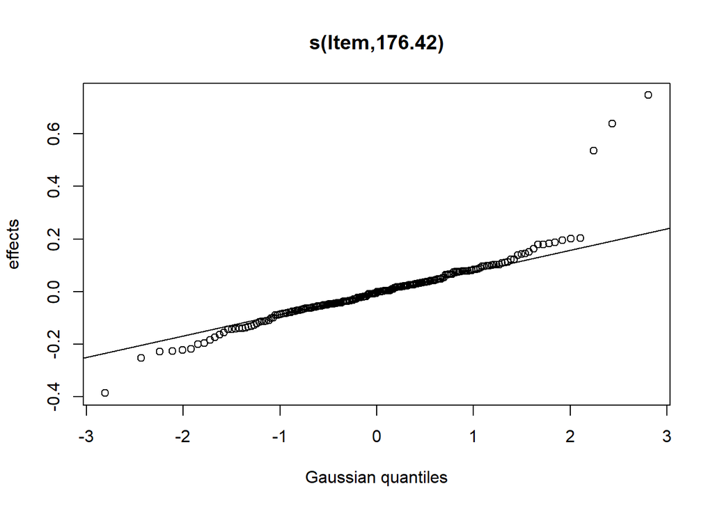

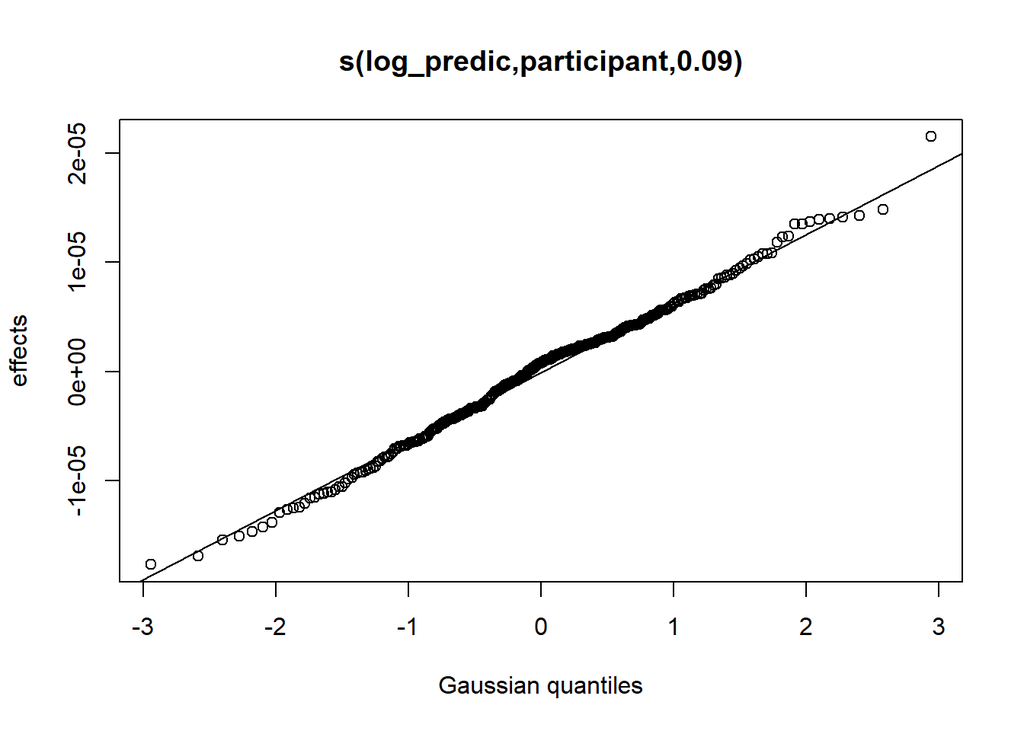

```r
plot(mod_bam_inter)
```

#### Let’s compare our model with phrasal vs nonphrasal in it using BIC

```r
models = list(mod_gam1, mod_gam_phrasal_nonphrasal)

map_df(models, glance, .id = 'model') %>%
  arrange(BIC)
```

```
## # A tibble: 2 × 8
##   model    df  logLik    AIC    BIC deviance df.residual  nobs
##   <chr> <dbl>   <dbl>  <dbl>  <dbl>    <dbl>       <dbl> <int>
## 1 1      523. -16223. 33498. 37802.    5285.      25824. 26347
## 2 2      524. -16223. 33499. 37807.    5285.      25823. 26347
```

The BIC analysis suggests the model with phrasal verb as an interaction is not any better than our original model.

Let’s run separate analyses for phrasal and non-phrasal verbs:

```r
gam_data$PhrasalVerb = as.factor(gam_data$PhrasalVerb)

gam_data_phrasal = gam_data %>%
  filter(PhrasalVerb == 'phrasal')


mod_gam_phrasal = bam(log_rt ~  #note that RT is log seconds
                 te(log_predic, log_freq) + Duration + trial +
                 s(participant, bs = 're') +
                 s(Item, bs = 're') +
                 s(log_predic, log_freq, participant, bs = 're'),
              #method = 'REML',
               #optimizer = 'perf',
              data = gam_data_phrasal)

summary(mod_gam_phrasal)
```

```
##
## Family: gaussian
## Link function: identity
##
## Formula:
## log_rt ~ te(log_predic, log_freq) + Duration + trial + s(participant,
##     bs = "re") + s(Item, bs = "re") + s(log_predic, log_freq,
##     participant, bs = "re")
##
## Parametric coefficients:
##               Estimate Std. Error t value Pr(>|t|)
## (Intercept)  4.178e-02  5.170e-02   0.808 0.419063
## Duration    -1.961e+00  5.784e-01  -3.390 0.000701 ***
## trial        1.282e-04  3.819e-05   3.358 0.000788 ***
## ---
## Signif. codes:  0 '***' 0.001 '**' 0.01 '*' 0.05 '.' 0.1 ' ' 1
##
## Approximate significance of smooth terms:
##                                          edf  Ref.df     F p-value
## te(log_predic,log_freq)            3.919e+00   3.967  1.11   0.298
## s(participant)                     2.896e+02 305.000 20.84  <2e-16 ***
## s(Item)                            1.003e+02 111.000 11.29  <2e-16 ***
## s(log_predic,log_freq,participant) 9.586e-04 305.000  0.00   0.727
## ---
## Signif. codes:  0 '***' 0.001 '**' 0.01 '*' 0.05 '.' 0.1 ' ' 1
##
## R-sq.(adj) =  0.322   Deviance explained =   34%
## fREML =  10788  Scale est. = 0.22387   n = 15169
```

```r
saveRDS(mod_gam_phrasal, 'mod_gam_phrasal.rds')

gam_data_nonphrasal = gam_data %>%
  filter(PhrasalVerb == 'nonphrasal')

mod_gam_nonphrasal = bam(log_rt ~  #note that RT is log seconds
                 te(log_predic, log_freq) + Duration + trial +
                 s(participant, bs = 're') +
                 s(Item, bs = 're') +
                 s(log_predic, log_freq, participant, bs = 're'),
              #method = 'REML',
               #optimizer = 'perf',
              data = gam_data_nonphrasal)

summary(mod_gam_nonphrasal)
```

```
##
## Family: gaussian
## Link function: identity
##
## Formula:
## log_rt ~ te(log_predic, log_freq) + Duration + trial + s(participant,
##     bs = "re") + s(Item, bs = "re") + s(log_predic, log_freq,
##     participant, bs = "re")
##
## Parametric coefficients:
##               Estimate Std. Error t value Pr(>|t|)
## (Intercept) -5.884e-02  6.411e-02  -0.918   0.3587
## Duration    -1.429e+00  6.935e-01  -2.060   0.0394 *
## trial        3.742e-04  4.001e-05   9.354   <2e-16 ***
## ---
## Signif. codes:  0 '***' 0.001 '**' 0.01 '*' 0.05 '.' 0.1 ' ' 1
##
## Approximate significance of smooth terms:
##                                          edf  Ref.df    F p-value
## te(log_predic,log_freq)            3.978e+00   4.026  1.5   0.201
## s(participant)                     2.869e+02 305.000 16.7  <2e-16 ***
## s(Item)                            7.102e+01  79.000 11.3  <2e-16 ***
## s(log_predic,log_freq,participant) 2.303e-03 305.000  0.0   0.554
## ---
## Signif. codes:  0 '***' 0.001 '**' 0.01 '*' 0.05 '.' 0.1 ' ' 1
##
## R-sq.(adj) =  0.351   Deviance explained = 37.2%
## fREML = 6792.1  Scale est. = 0.17885   n = 11178
```

```r
saveRDS(mod_gam_nonphrasal, 'mod_gam_nonphrasal.rds')
```

### Word Internal Analysis

```r
word_internal_analysis = data_analysis %>%
  filter(Type == 'Word-Internal')

mod_gam_word_internal = bam(log_rt ~  #note that RT is log seconds
                 s(log_freq) + Duration + trial +
                 s(participant, bs = 're') +
                 s(Item, bs = 're') +
                 s(log_freq, participant, bs = 're'),
              #method = 'REML',
               #optimizer = 'perf',
              data = word_internal_analysis)

summary(mod_gam_word_internal)
```

```
##
## Family: gaussian
## Link function: identity
##
## Formula:
## log_rt ~ s(log_freq) + Duration + trial + s(participant, bs = "re") +
##     s(Item, bs = "re") + s(log_freq, participant, bs = "re")
##
## Parametric coefficients:
##               Estimate Std. Error t value Pr(>|t|)
## (Intercept)  3.386e-01  9.245e-02   3.662 0.000251 ***
## Duration    -1.565e+00  1.023e+00  -1.529 0.126292
## trial        9.180e-05  3.576e-05   2.567 0.010254 *
## ---
## Signif. codes:  0 '***' 0.001 '**' 0.01 '*' 0.05 '.' 0.1 ' ' 1
##
## Approximate significance of smooth terms:
##                             edf Ref.df      F p-value
## s(log_freq)               1.740   1.75  1.076   0.222
## s(participant)          289.963 305.00 21.277  <2e-16 ***
## s(Item)                 142.511 147.00 42.365  <2e-16 ***
## s(log_freq,participant)   6.911 305.00  0.027   0.376
## ---
## Signif. codes:  0 '***' 0.001 '**' 0.01 '*' 0.05 '.' 0.1 ' ' 1
##
## R-sq.(adj) =   0.36   Deviance explained = 37.3%
## fREML =  18696  Scale est. = 0.28916   n = 22457
```

### Brms quadratic

```r
options(contrasts = c("contr.sum","contr.sum"))
#let's use weakly informative priors for our beta coefficients are student_t with mean slightly negative (let's say -0.05) and standard deviation of 0.1.
priors = c(prior(student_t(3, 0, 2.5), class = 'sd'),     #pretty standard sd and sigma priors
           prior(student_t(3, 0, 2.5), class = 'sigma'),
           #prior(lkj(1), class = 'cor'),
           prior(student_t(3, 0, 2.5), class = 'Intercept'),  #slightly negative intercept
           prior(normal(0, 0.1), class = 'b')) #slightly negative prior for beta coefficients
brms_quadratic_no_interaction = brm(log_rt ~ log_freq + log_predic + Duration + #fixed-effects
                        I(log_predic^2) + I(log_freq^2) + #quadratic component
                       (1 + log_freq + log_predic + Duration + I(log_predic^2) + I(log_freq^2) || participant) + (1||Item), #random effects
                     data = gam_data,
                     warmup = 10000,
                     iter = 20000,
                     cores = 8,
                     chains = 8,
                     init = 0,
                     control = list(adapt_delta = 0.99),
                     prior = priors,
                     file = 'brms_quadratic_english_no_interaction')


fixef(brms_quadratic_no_interaction)
```

```
##                   Estimate   Est.Error         Q2.5        Q97.5
## Intercept     -0.102405352 0.029385936 -0.160568664 -0.045543769
## log_freq       0.019273235 0.010863932 -0.002120436  0.040660136
## log_predic     0.009243217 0.011459213 -0.013122420  0.031759309
## Duration      -0.135244652 0.097626972 -0.327780475  0.056679051
## Ilog_predicE2  0.003291746 0.001774803 -0.000169995  0.006781445
## Ilog_freqE2    0.005300445 0.003599828 -0.001815508  0.012353281
```

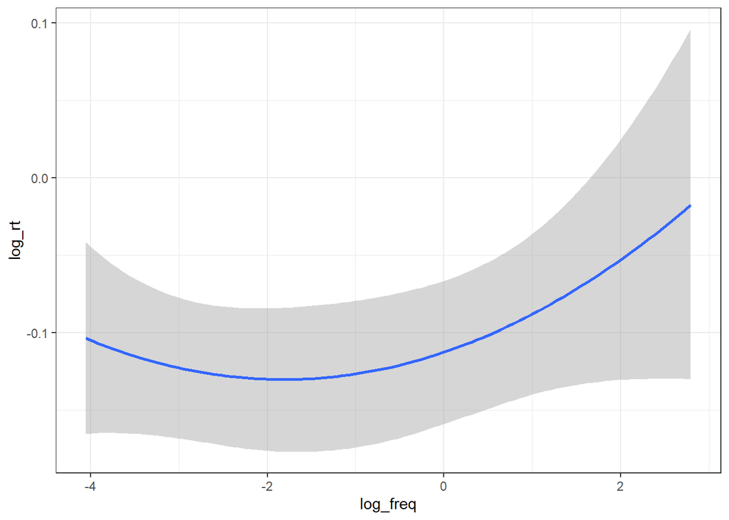

```r
brms_plot = conditional_effects(brms_quadratic_no_interaction)

freq_plot = plot(brms_plot, plot = F)[[1]] +
  theme_bw()

predic_plot = plot(brms_plot, plot = F)[[2]] +
  theme_bw()

freq_plot
```

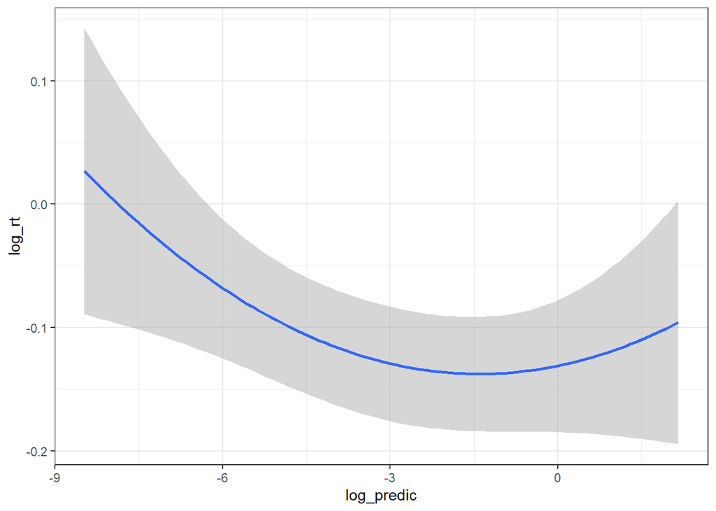

```r
predic_plot #need a way to plot these together, ggarrange isn't working
```

### Follow-up brms models (quadratic with only frequency, quadratic with only predictability)

Frequency quadratic

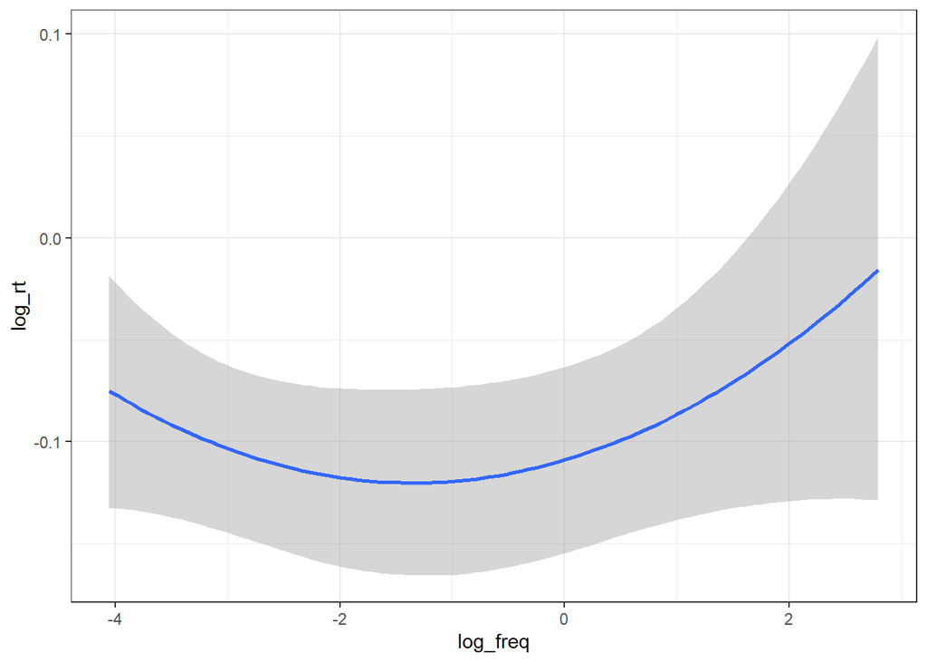

```r
options(contrasts = c("contr.sum","contr.sum"))
#let's use weakly informative priors for our beta coefficients are student_t with mean slightly negative (let's say -0.05) and standard deviation of 0.1.
priors = c(prior(student_t(3, 0, 2.5), class = 'sd'),     #pretty standard sd and sigma priors
           prior(student_t(3, 0, 2.5), class = 'sigma'),
           #prior(lkj(1), class = 'cor'),
           prior(student_t(3, 0, 2.5), class = 'Intercept'),  #slightly negative intercept
           prior(normal(0, 0.1), class = 'b')) #slightly negative prior for beta coefficients
brms_freq_quadratic_no_interaction = brm(log_rt ~ log_freq + Duration + #fixed-effects
                       I(log_freq^2) + #quadratic component
                       (1 + log_freq + Duration + I(log_freq^2) || participant) + (1||Item), #random effects
                     data = gam_data,
                     warmup = 5000,
                     iter = 10000,
                     cores = 8,
                     chains = 8,
                     init = 0,
                     control = list(adapt_delta = 0.99),
                     prior = priors,
                     file = 'brms_freq_quadratic_english_no_interaction')

brms_freq_plot = conditional_effects(brms_freq_quadratic_no_interaction)

freq_plot = plot(brms_freq_plot, plot = F)[[1]] +
  theme_bw()

freq_plot
```

Predictability quadratic:

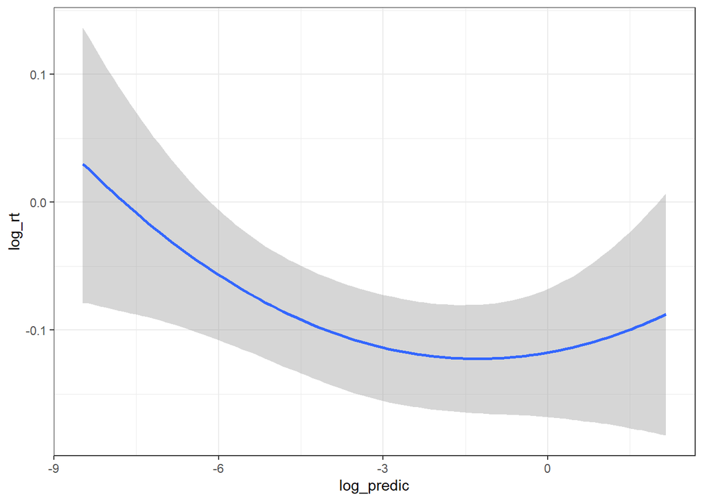

```r
options(contrasts = c("contr.sum","contr.sum"))
#let's use weakly informative priors for our beta coefficients are student_t with mean slightly negative (let's say -0.05) and standard deviation of 0.1.
priors = c(prior(student_t(3, 0, 2.5), class = 'sd'),     #pretty standard sd and sigma priors
           prior(student_t(3, 0, 2.5), class = 'sigma'),
           #prior(lkj(1), class = 'cor'),
           prior(student_t(3, 0, 2.5), class = 'Intercept'),  #slightly negative intercept
           prior(normal(0, 0.1), class = 'b')) #slightly negative prior for beta coefficients
brms_predic_quadratic_no_interaction = brm(log_rt ~  log_predic + Duration + #fixed-effects
                        I(log_predic^2) + #quadratic component
                       (1 + log_predic + Duration + I(log_predic^2) || participant) + (1||Item), #random effects
                     data = gam_data,
                     warmup = 5000,
                     iter = 10000,
                     cores = 8,
                     chains = 8,
                     init = 0,
                     control = list(adapt_delta = 0.99),
                     prior = priors,
                     file = 'brms_predic_quadratic_english_no_interaction')

brms_predic_plot = conditional_effects(brms_predic_quadratic_no_interaction)
predic_plot = plot(brms_predic_plot, plot = F)[[1]] +
  theme_bw()

predic_plot
```

```r
brms_quadratic = brm(log_rt ~ log_freq * log_predic * PhrasalVerb * Duration + #fixed-effects
                        I(log_predic^2) * log_freq * PhrasalVerb * Duration + #quadratic component
                       (1 + log_freq * log_predic * PhrasalVerb * Duration + I(log_predic^2) * log_freq * PhrasalVerb * Duration | participant) + (1|Item), #random effects
                     data = gam_data,
                     warmup = 6000,
                     iter = 12000,
                     cores = 8,
                     chains = 8,
                     init = 0,
                     prior = priors,
                     file = 'brms_quadratic_english')


fixef(brms_quadratic)



brms_quadratic_no_phrasal = brm(log_rt ~ log_freq * log_predic * Duration + #fixed-effects
                        I(log_predic^2) * log_freq * Duration + #quadratic component
                       (1 + log_freq * log_predic * Duration + I(log_predic^2) * log_freq * Duration | participant) + (1|Item), #random effects
                     data = gam_data,
                     warmup = 6000,
                     iter = 12000,
                     cores = 8,
                     chains = 8,
                     init = 0,
                     prior = priors,
                     file = 'brms_quadratic_no_phrasal')


fixef(brms_quadratic_no_phrasal)


bayesian_full_quadratic_english = brm(log_rt ~ log_freq * log_predic * PhrasalVerb * Duration + #fixed-effects
                        I(log_predic^2) * log_freq * PhrasalVerb * Duration + #quadratic component
                          I(log_freq^2) * log_predic * PhrasalVerb * Duration +
                          I(log_freq^2) * I(log_predic^2) * PhrasalVerb * Duration +
                       (1 + log_freq * log_predic * PhrasalVerb * Duration +
                          I(log_predic^2) * log_freq * PhrasalVerb * Duration +
                          I(log_freq^2) * log_predic * PhrasalVerb * Duration +
                          I(log_freq^2) * I(log_predic^2) * PhrasalVerb * Duration | participant) + (1|Item), #random effects
                     data = gam_data_english,
                     warmup = 6000,
                     iter = 12000,
                     cores = 8,
                     chains = 8,
                     init = 0,
                     prior = priors,
                     file = 'brms_full_quadratic_english')



bayesian_full_quadratic_english_no_phrasalverb = brm(log_rt ~ log_freq * log_predic * Duration + #fixed-effects
                        I(log_predic^2) * log_freq  * Duration + #quadratic component
                          I(log_freq^2) * log_predic * Duration +
                          I(log_freq^2) * I(log_predic^2) * Duration +
                       (1 + log_freq * log_predic * Duration +
                          I(log_predic^2) * log_freq * Duration +
                          I(log_freq^2) * log_predic * Duration +
                          I(log_freq^2) * I(log_predic^2) * Duration || participant) + (1||Item), #random effects
                     data = gam_data_English_final,
                     warmup = 3000,
                     iter = 6000,
                     control = list(adapt_delta = 0.9, max_treedepth = 13),
                     cores = 8,
                     chains = 8,
                     init = 0,
                     prior = priors,
                     file = 'brms_full_quadratic_english_no_phrasalverb')
```

Percentage of samples greater than zero for the quadratic predictors

```r
post_samples = as.data.frame(fixef(brms_quadratic_no_interaction, summary = F)) %>%
  select(Ilog_predicE2, Ilog_freqE2, log_freq, log_predic)

#number of freq^2 samples greater than zero

sum(post_samples$Ilog_freqE2 > 0) / length(post_samples$Ilog_freqE2)
```

```
## [1] 0.9294375
```

```r
#number of predic^2 samples greater than zero

sum(post_samples$Ilog_predicE2 > 0) / length(post_samples$Ilog_predicE2) #almost 97% of samples are greater than zero lol
```

```
## [1] 0.9688125
```

```r
sum(post_samples$log_freq > 0) / length(post_samples$log_freq)
```

```
## [1] 0.9615625
```

```r
sum(post_samples$log_predic > 0) / length(post_samples$log_predic)
```

```
## [1] 0.789975
```

### Plots of the beta distributions for our predictors for each brms model:

#### Full Quadratic

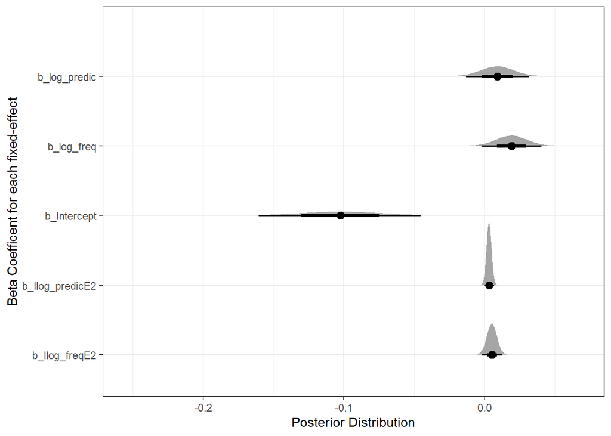

```r
#post_samples_full_quadratic = as.data.frame(fixef(brms_quadratic_no_interaction, summary = F))

brms_quadratic_no_interaction %>%
  gather_draws(b_Intercept, b_log_freq, b_log_predic, b_Ilog_predicE2, b_Ilog_freqE2) %>%
  ggplot(aes(x = .value, y = .variable)) +
  stat_halfeye() +
  xlab('Posterior Distribution') +
  ylab('Beta Coefficent for each fixed-effect') +
  theme_bw()
```

#### Freq Quadratic

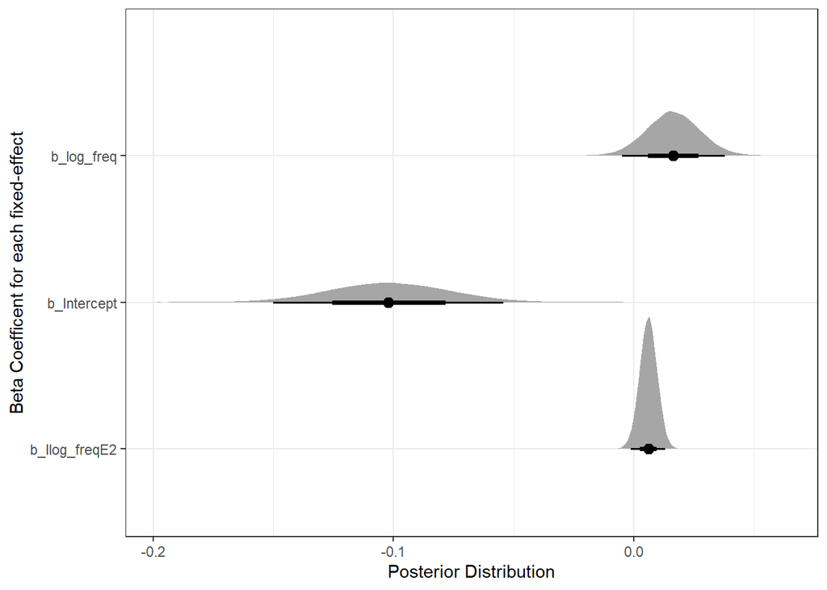

```r
brms_freq_quadratic_no_interaction %>%
  gather_draws(b_Intercept, b_log_freq, b_Ilog_freqE2) %>%
  ggplot(aes(x = .value, y = .variable)) +
  stat_halfeye() +
  xlab('Posterior Distribution') +
  ylab('Beta Coefficent for each fixed-effect') +
  theme_bw()
```

```r
post_samples_freq = as.data.frame(fixef(brms_freq_quadratic_no_interaction, summary = F)) %>%
  select(log_freq, Ilog_freqE2)

sum(post_samples_freq$Ilog_freqE2 > 0) / length(post_samples_freq$Ilog_freqE2)
```

```
## [1] 0.95225
```

```r
#number of predic^2 samples greater than zero

sum(post_samples_freq$log_freq > 0) / length(post_samples_freq$log_freq)
```

```
## [1] 0.9331
```

#### Predic

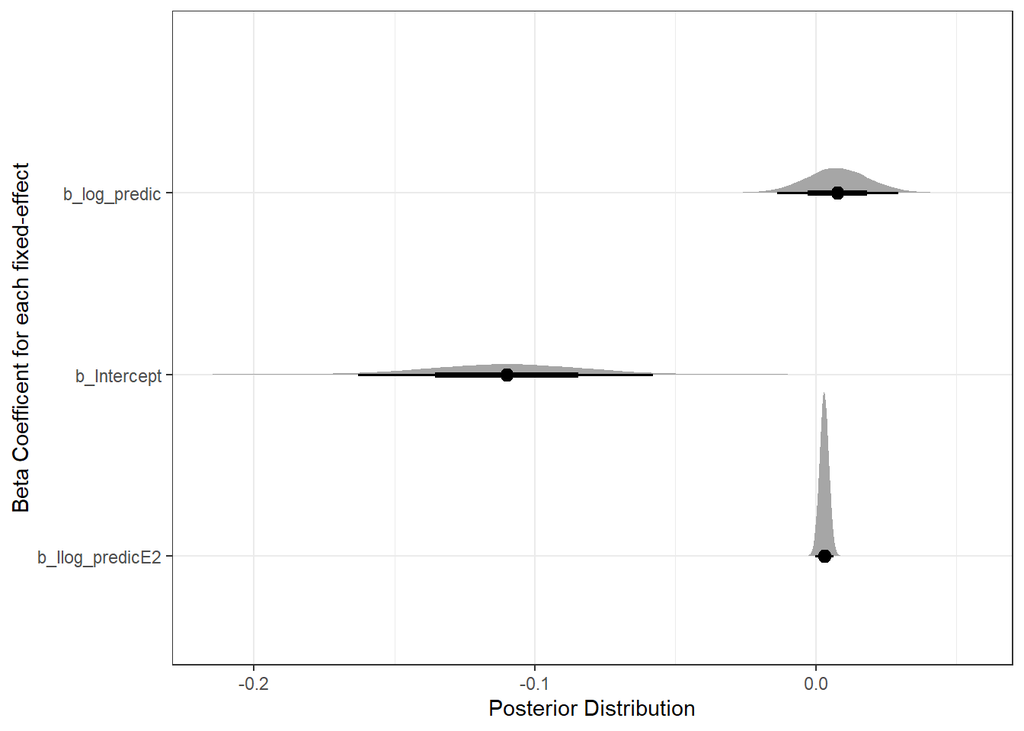

```r
brms_predic_quadratic_no_interaction %>%
  gather_draws(b_Intercept, b_log_predic, b_Ilog_predicE2) %>%
  ggplot(aes(x = .value, y = .variable)) +
  stat_halfeye() +
  xlab('Posterior Distribution') +
  ylab('Beta Coefficent for each fixed-effect') +
  theme_bw()
```

```r
post_samples_predic = as.data.frame(fixef(brms_predic_quadratic_no_interaction, summary = F)) %>%
  select(log_predic, Ilog_predicE2)


sum(post_samples_predic$Ilog_predicE2 > 0) / length(post_samples_predic$Ilog_predicE2) #almost 97% of samples are greater than zero lol
```

```
## [1] 0.960975
```

```r
sum(post_samples_predic$log_predic > 0) / length(post_samples_predic$log_predic)
```

```
## [1] 0.75735
```

### Plots

Let’s start with a really simple rt ~ frequency graph and rt ~ predictability graph:

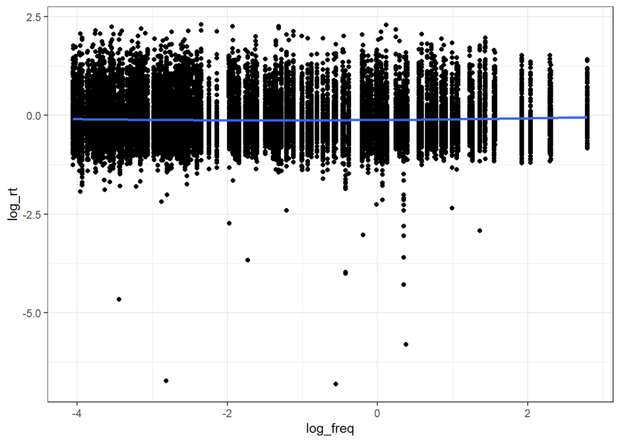

```r
rt_freq = ggplot(data = gam_data) +
  geom_point(aes(x = log_freq, y = log_rt)) +
  geom_smooth(aes(x = log_freq, y = log_rt), method = 'lm', formula = y~x + I(x^2), size = 1) +
  theme_bw()
rt_freq
```

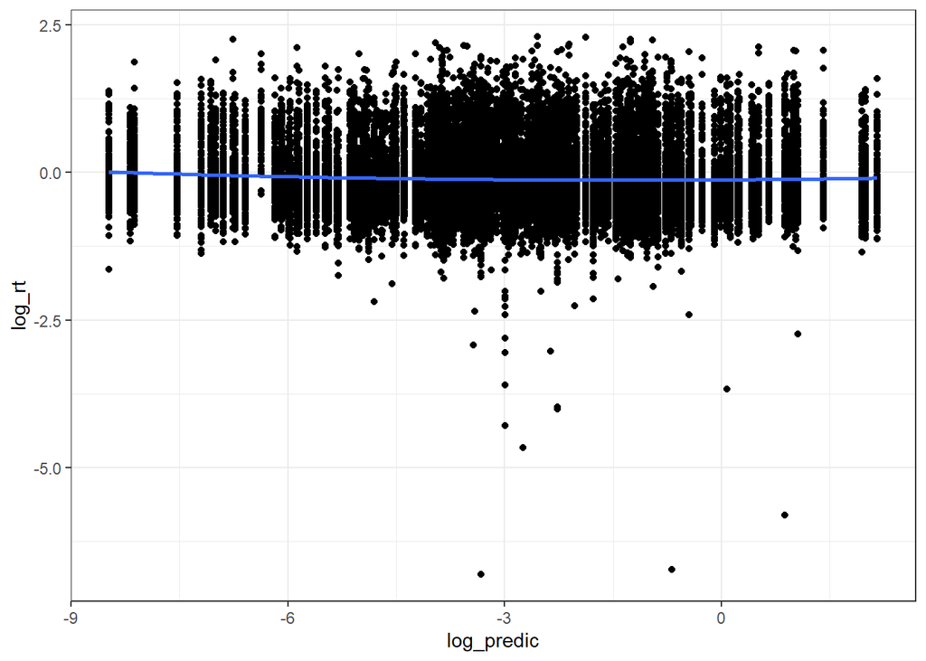

```r
rt_predic = ggplot(data = gam_data) +
  geom_point(aes(x = log_predic, y = log_rt)) +
  geom_smooth(aes(x = log_predic, y = log_rt), method = 'lm', formula = y~ x + I(x^2), size = 1) +
  theme_bw()

rt_predic
```

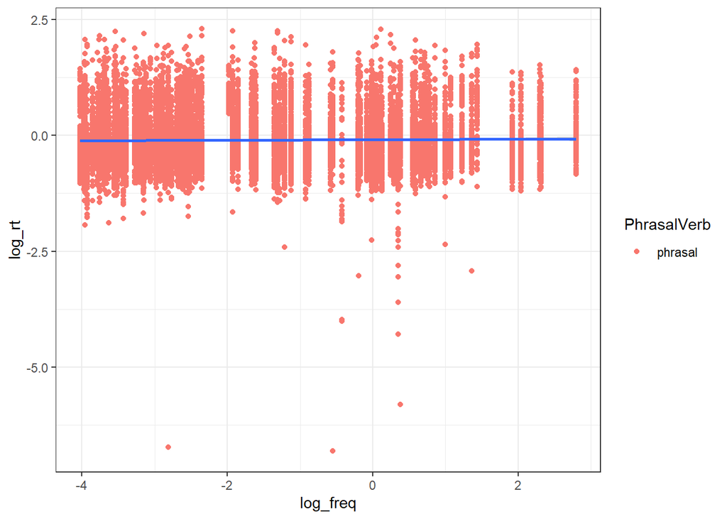

```r
### different plots for PhrasalVerb == 0 and PhrasalVerb == 1

rt_phrasal_data = gam_data %>%
  filter(PhrasalVerb == 'phrasal')

rt_nonphrasal_data = gam_data %>%
  filter(PhrasalVerb == 'nonphrasal')

rt_freq_phrasal = ggplot(data = rt_phrasal_data) +
  geom_point(aes(x = log_freq, y = log_rt, color = PhrasalVerb)) +
  geom_smooth(aes(x = log_freq, y = log_rt), method = 'lm', formula = y~x + I(x^2), size = 1) +
  theme_bw()

rt_freq_nonphrasal = ggplot(data = rt_nonphrasal_data) +
  geom_point(aes(x = log_freq, y = log_rt, color = PhrasalVerb)) +
  geom_smooth(aes(x = log_freq, y = log_rt), method = 'lm', formula = y~x + I(x^2), size = 1) +
  theme_bw()


rt_predic_phrasal = ggplot(data = rt_phrasal_data) +
  geom_point(aes(x = log_predic, y = log_rt, color = PhrasalVerb)) +
  geom_smooth(aes(x = log_predic, y = log_rt), method = 'lm', formula = y~x + I(x^2), size = 1) +
  theme_bw()

rt_predic_nonphrasal = ggplot(data = rt_nonphrasal_data) +
  geom_point(aes(x = log_predic, y = log_rt, color = PhrasalVerb)) +
  geom_smooth(aes(x = log_predic, y = log_rt), method = 'lm', formula = y~x + I(x^2), size = 1) +
  theme_bw()

rt_freq_phrasal
```

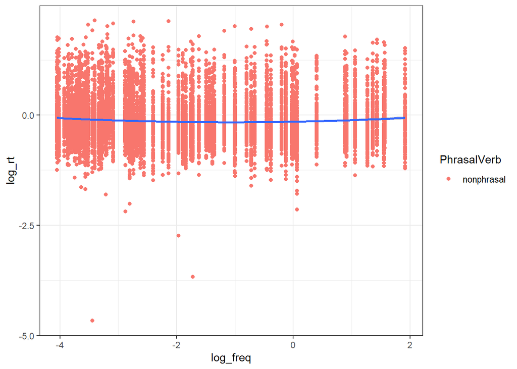

```r
rt_freq_nonphrasal
```

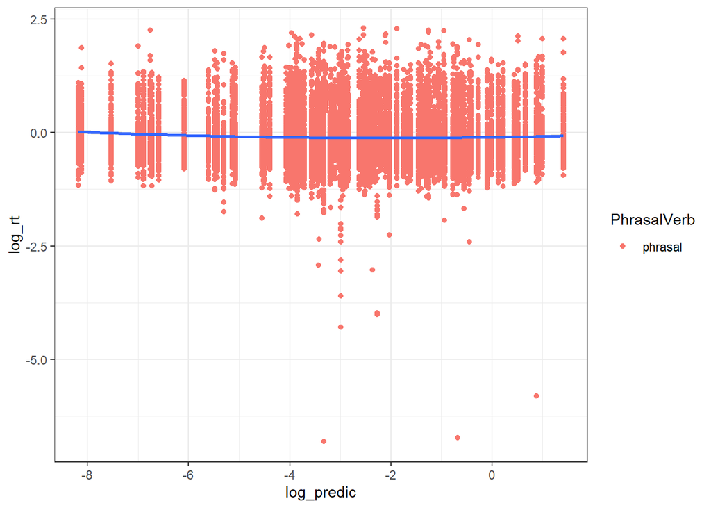

```r
rt_predic_phrasal
```

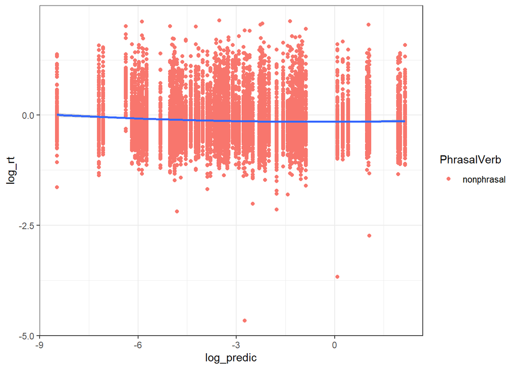

```r
rt_predic_nonphrasal
```

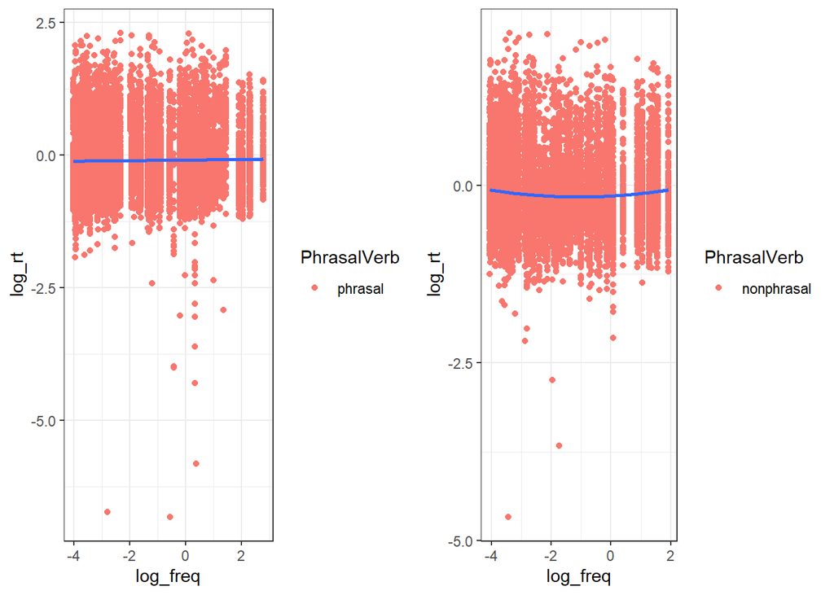

```r
ggarrange(rt_freq_phrasal, rt_freq_nonphrasal, nrow = 1)
```

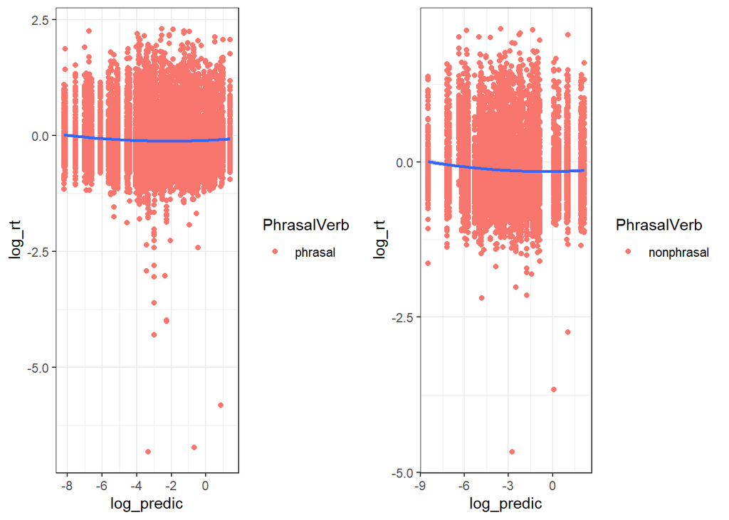

```r
ggarrange(rt_predic_phrasal, rt_predic_nonphrasal, nrow = 1)
```

```r
png(file = 'main_effect_plot1.png')
vis.gam(mod_gam1,
        view = c('log_predic', 'log_freq'),
        type = 'response',
        plot.type = 'persp',
        phi = 30,
        theta = 30,
        n.grid = 500,
        xlab = 'Predictability (log)',
        ylab = 'Frequency (log)',
        zlab = 'Predicted RT (log)',
        #too.far = 0.01,
        border = NA)
dev.off()
```

```r
png(file = 'main_effect_phrasal_plot1.png')
vis.gam(mod_gam_phrasal,
        view = c('log_predic', 'log_freq'),
        type = 'response',
        plot.type = 'persp',
        phi = 30,
        theta = 30,
        n.grid = 500,
        xlab = 'Predictability (log)',
        ylab = 'Frequency (log)',
        zlab = 'Predicted RT (log)',
        #too.far = 0.01,
        border = NA)
dev.off()
```

```r
png(file = 'main_effect_nonphrasal_plot1.png')
vis.gam(mod_gam_nonphrasal,
        view = c('log_predic', 'log_freq'),
        type = 'response',
        plot.type = 'persp',
        phi = 30,
        theta = 30,
        n.grid = 500,
        xlab = 'Predictability (log)',
        ylab = 'Frequency (log)',
        zlab = 'Predicted RT (log)',
        #too.far = 0.01,
        border = NA)
dev.off()
```

```r
png(file = 'main_effect_nonphrasal_plot2.png')
vis.gam(mod_gam_phrasal_nonphrasal,
        view = c('log_predic', 'log_freq'),
        cond = list(PhrasalVerb='nonphrasal'),
        type = 'response',
        plot.type = 'persp',
        phi = 30,
        theta = 30,
        n.grid = 500,
        xlab = 'Predictability (log)',
        ylab = 'Frequency (log)',
        zlab = 'Predicted RT (log)',
        #too.far = 0.01,
        border = NA)
dev.off()
```

```r
png(file = 'main_effect_phrasal_plot2.png')
vis.gam(mod_gam_phrasal_nonphrasal,
        view = c('log_predic', 'log_freq'),
        cond = list(PhrasalVerb='phrasal'),
        type = 'response',
        plot.type = 'persp',
        phi = 30,
        theta = 30,
        n.grid = 500,
        xlab = 'Predictability (log)',
        ylab = 'Frequency (log)',
        zlab = 'Predicted RT (log)',
        #too.far = 0.01,
        border = NA)
dev.off()
```

2d plots that show our data as well:

```r
#main effect plot
png(file = 'main_effect_plot_2d.png', width = 800)
plot(sm(getViz(mod_gam1), 1)) + l_fitRaster() + l_fitContour() + l_points(shape = 19, size = 1.5, alpha = 0.1) + xlab('Predictability (log)') + ylab('Frequency (log)') + ggtitle(NULL) + scale_fill_viridis_c(breaks = c(0.0, 0.1, 0.2), name = 's(x)', labels = c('0.0', '0.1', '0.2'))
dev.off()
```

```r
#graph of GAM run on only phrasal verbs
#png(file = 'phrasal_plot_2d.png', width = 800)
#plot(sm(getViz(mod_gam_phrasal), 1)) + l_fitRaster() + l_fitContour() + l_points(shape = 19, size = 1.5, alpha = 0.1) + xlab('Predictability (log)') + ylab('Frequency (log)') + ggtitle(NULL) + scale_fill_viridis_c(breaks = c(0.0, 0.1, 0.2), name = 's(x)', labels = c('0.0', '0.1', '0.2'))
#dev.off()

#graph of GAM run on only nonphrasal verbs
#png(file = 'nonphrasal_plot_2d.png', width = 800)
#plot(sm(getViz(mod_gam_nonphrasal), 1)) + l_fitRaster() + l_fitContour() + l_points(shape = 19, size = 1.5, alpha = 0.1) + xlab('Predictability (log)') + ylab('Frequency (log)') + ggtitle(NULL) + scale_fill_viridis_c(breaks = c(0.0, 0.1, 0.2), name = 's(x)', labels = c('0.0', '0.1', '0.2'))
#dev.off()

#graph of interaction effect for nonphrasal verbs in GAM with both phrasal and nonphrasal verbs
#png(file = 'phrasal_nonphrasal_plot1_2d.png', width = 800)
#plot(sm(getViz(mod_gam_phrasal_nonphrasal), 1)) + l_fitRaster() + l_fitContour() + l_points(shape = 19, size = 1.5, alpha = 0.1) + xlab('Predictability (log)') + ylab('Frequency (log)') + ggtitle(NULL) + scale_fill_viridis_c(breaks = c(0.0, 0.1, 0.2), name = 's(x)', labels = c('0.0', '0.1', '0.2'))
#dev.off()

#graph of interaction effect for phrasal verbs in GAM with both phrasal and nonphrasal verbs
#png(file = 'phrasal_nonphrasal_plot2_2d.png', width = 800)
#plot(sm(getViz(mod_gam_phrasal_nonphrasal), 2)) + l_fitRaster() + l_fitContour() + l_points(shape = 19, size = 1.5, alpha = 0.1) + xlab('Predictability (log)') + ylab('Frequency (log)') + ggtitle(NULL) + theme(axis.text=element_text(size=12),) + scale_fill_viridis_c(breaks = c(0.0, 0.1, 0.2), name = 's(x)', labels = c('0.0', '0.1', '0.2'))
#dev.off()

#plot1 = plot(sm(getViz(mod_gam_phrasal_nonphrasal), 1)) + l_fitRaster() + l_fitContour() + l_points(shape = 19, size = 1.5, alpha = 0.1) + xlab('Predictability (log)') + ylab('Frequency (log)') + ggtitle(NULL) + scale_fill_viridis_c(breaks = c(0.0, 0.1, 0.2), name = 's(x)', labels = c('0.0', '0.1', '0.2'))

#plot2 = plot(sm(getViz(mod_gam_phrasal_nonphrasal), 2)) + l_fitRaster() + l_fitContour() + l_points(shape = 19, size = 1.5, alpha = 0.1) + xlab('Predictability (log)') + ylab('Frequency (log)') + ggtitle(NULL) + scale_fill_viridis_c(breaks = c(0.0, 0.1, 0.2), name = 's(x)', labels = c('0.0', '0.1', '0.2'))

#gridPrint(plot1, plot2, ncol = 1)
```

```r
#gridPrint(pl, pl2)
```

#### Saving the plots and models for the write-up

```r
saveRDS(object = plot_3d, file = 'plot_3d.rds')
```